# Mortality_Analysis

Now the final calculation is to compare mortality rates between South Korea, Germany and Singapore. Taking into considertation that the first 2 were successful in confirming about half of the cases and Singapore has been capable of tracking all cases

```r
#Calculate divisor for Germany and Korea based on population above 60. More than 300 confirmed cases in Singapore
#Germany and Korea most likely did not confirm all covid cases

#This point calculation should be redone for all cases over 60 to be proportional
#reduce variance average
#But we have to adjust porportions based on cases


#in Germany Proportionaly they tested many more people over 80 compared to South Korea
Germany.Ratio.80.60 = Confirmed.Cases.Deaths[Confirmed.Cases.Deaths$Country=="Germany" & Confirmed.Cases.Deaths$Age.Group == "A80+","Number.of.cases"] / Confirmed.Cases.Deaths[Confirmed.Cases.Deaths$Country=="Germany" & Confirmed.Cases.Deaths$Age.Group == "A60-A79","Number.of.cases"]

Germany.Ratio.80.tototal = Confirmed.Cases.Deaths[Confirmed.Cases.Deaths$Country=="Germany" & Confirmed.Cases.Deaths$Age.Group == "A80+","Number.of.cases"] / (Confirmed.Cases.Deaths[Confirmed.Cases.Deaths$Country=="Germany" & Confirmed.Cases.Deaths$Age.Group == "A60-A79","Number.of.cases"]+Confirmed.Cases.Deaths[Confirmed.Cases.Deaths$Country=="Germany" & Confirmed.Cases.Deaths$Age.Group == "A80+","Number.of.cases"])

Germany.Ratio.60.tototal = 1-Germany.Ratio.80.tototal

Korea.Ratio.80.60 = Confirmed.Cases.Deaths[Confirmed.Cases.Deaths$Country=="South Korea" & Confirmed.Cases.Deaths$Age.Group == "A80+","Number.of.cases"] / Confirmed.Cases.Deaths[Confirmed.Cases.Deaths$Country=="South Korea" & Confirmed.Cases.Deaths$Age.Group == "A60-A79","Number.of.cases"]

Korea.Ratio.80.tototal = Confirmed.Cases.Deaths[Confirmed.Cases.Deaths$Country=="South Korea" & Confirmed.Cases.Deaths$Age.Group == "A80+","Number.of.cases"] / (Confirmed.Cases.Deaths[Confirmed.Cases.Deaths$Country=="South Korea" & Confirmed.Cases.Deaths$Age.Group == "A60-A79","Number.of.cases"]+Confirmed.Cases.Deaths[Confirmed.Cases.Deaths$Country=="South Korea" & Confirmed.Cases.Deaths$Age.Group == "A80+","Number.of.cases"])

Korea.Ratio.60.tototal=1-Korea.Ratio.80.tototal

#ratio comparing South Kore to Singapore is much closer. This has to be taken into consideration. Normalizing the number of cases is important
Singapore.Ratio.80.60 = Confirmed.Cases.Deaths[Confirmed.Cases.Deaths$Country=="Singapore" & Confirmed.Cases.Deaths$Age.Group == "A80+","Number.of.cases"] / Confirmed.Cases.Deaths[Confirmed.Cases.Deaths$Country=="Singapore" & Confirmed.Cases.Deaths$Age.Group == "A60-A79","Number.of.cases"]

Singapore.Ratio.80.tototal = Confirmed.Cases.Deaths[Confirmed.Cases.Deaths$Country=="Singapore" & Confirmed.Cases.Deaths$Age.Group == "A80+","Number.of.cases"] / (Confirmed.Cases.Deaths[Confirmed.Cases.Deaths$Country=="Singapore" & Confirmed.Cases.Deaths$Age.Group == "A60-A79","Number.of.cases"]+Confirmed.Cases.Deaths[Confirmed.Cases.Deaths$Country=="Singapore" & Confirmed.Cases.Deaths$Age.Group == "A80+","Number.of.cases"])

Singapore.Ratio.60.tototal = 1- Singapore.Ratio.80.tototal

Germany.Ratio.60.tototal
```

```
## [1] 0.6301771
```

```r
Korea.Ratio.60.tototal
```

```
## [1] 0.8191282
```

```r
Singapore.Ratio.60.tototal
```

```
## [1] 0.8762136
```

```r
#Germany a higher percentage of 80 year and above cases
#Have to align ratios to Singapore

Germany.Ratio.60.tototal/Singapore.Ratio.60.tototal #0.71 times
```

```
## [1] 0.7192049
```

```r
Germany.Ratio.80.tototal/Singapore.Ratio.80.tototal #2.98 more times
```

```
## [1] 2.987589
```

```r
#have to divide cases and deaths to balance for Germany

Death80temp = Confirmed.Cases.Deaths[Confirmed.Cases.Deaths$Country=="Germany" & Confirmed.Cases.Deaths$Age.Group == "A80+","Number.Death"]/(Germany.Ratio.80.tototal/Singapore.Ratio.80.tototal)
Case80temp = Confirmed.Cases.Deaths[Confirmed.Cases.Deaths$Country=="Germany" & Confirmed.Cases.Deaths$Age.Group == "A80+","Number.of.cases"]/(Germany.Ratio.80.tototal/Singapore.Ratio.80.tototal)

Death60temp = Confirmed.Cases.Deaths[Confirmed.Cases.Deaths$Country=="Germany" & Confirmed.Cases.Deaths$Age.Group == "A60-A79","Number.Death"]/(Germany.Ratio.60.tototal/Singapore.Ratio.60.tototal)
Case60temp = Confirmed.Cases.Deaths[Confirmed.Cases.Deaths$Country=="Germany" & Confirmed.Cases.Deaths$Age.Group == "A60-A79","Number.of.cases"]/(Germany.Ratio.60.tototal/Singapore.Ratio.60.tototal)


Midpoint.Germany = (Death80temp+Death60temp)/(Case80temp+Case60temp)

#Midpoint.Germany = sum(Confirmed.Cases.Deaths[Confirmed.Cases.Deaths$Country=="Germany" & (Confirmed.Cases.Deaths$Age.Group == "A80+" | Confirmed.Cases.Deaths$Age.Group == "A60-A79"),"Number.Death"])/sum(Confirmed.Cases.Deaths[Confirmed.Cases.Deaths$Country=="Germany" & (Confirmed.Cases.Deaths$Age.Group == "A80+" | Confirmed.Cases.Deaths$Age.Group == "A60-A79"),"Number.of.cases"])

#Now do the same for Korea

Korea.Ratio.60.tototal/Singapore.Ratio.60.tototal # 0.9348
```

```
## [1] 0.9348499
```

```r
Korea.Ratio.80.tototal/Singapore.Ratio.80.tototal # 1.4611
```

```
## [1] 1.461161
```

```r
Death80temp = Confirmed.Cases.Deaths[Confirmed.Cases.Deaths$Country=="South Korea" & Confirmed.Cases.Deaths$Age.Group == "A80+","Number.Death"]/(Korea.Ratio.80.tototal/Singapore.Ratio.80.tototal)
Case80temp = Confirmed.Cases.Deaths[Confirmed.Cases.Deaths$Country=="South Korea" & Confirmed.Cases.Deaths$Age.Group == "A80+","Number.of.cases"]/(Korea.Ratio.80.tototal/Singapore.Ratio.80.tototal)

Death60temp = Confirmed.Cases.Deaths[Confirmed.Cases.Deaths$Country=="South Korea" & Confirmed.Cases.Deaths$Age.Group == "A60-A79","Number.Death"]/(Korea.Ratio.60.tototal/Singapore.Ratio.60.tototal)
Case60temp = Confirmed.Cases.Deaths[Confirmed.Cases.Deaths$Country=="South Korea" & Confirmed.Cases.Deaths$Age.Group == "A60-A79","Number.of.cases"]/(Korea.Ratio.60.tototal/Singapore.Ratio.60.tototal)


Midpoint.Korea= (Death80temp+Death60temp)/(Case80temp+Case60temp)

#Midpoint.Korea = sum(Confirmed.Cases.Deaths[Confirmed.Cases.Deaths$Country=="South Korea" & (Confirmed.Cases.Deaths$Age.Group == "A80+" | Confirmed.Cases.Deaths$Age.Group == "A60-A79"),"Number.Death"])/sum(Confirmed.Cases.Deaths[Confirmed.Cases.Deaths$Country=="South Korea" & (Confirmed.Cases.Deaths$Age.Group == "A80+" | Confirmed.Cases.Deaths$Age.Group == "A60-A79"),"Number.of.cases"])

Midpoint.Singapore = sum(Confirmed.Cases.Deaths[Confirmed.Cases.Deaths$Country=="Singapore" & (Confirmed.Cases.Deaths$Age.Group == "A80+" | Confirmed.Cases.Deaths$Age.Group == "A60-A79"),"Number.Death"])/sum(Confirmed.Cases.Deaths[Confirmed.Cases.Deaths$Country=="Singapore" & (Confirmed.Cases.Deaths$Age.Group == "A80+" | Confirmed.Cases.Deaths$Age.Group == "A60-A79"),"Number.of.cases"])





Divisor.Germany = Midpoint.Germany/Midpoint.Singapore
Divisor.Korea = Midpoint.Korea/Midpoint.Singapore

Divisor.Germany
```

```
## [1] 2.360919
```

```r
Divisor.Korea
```

```
## [1] 1.688013
```

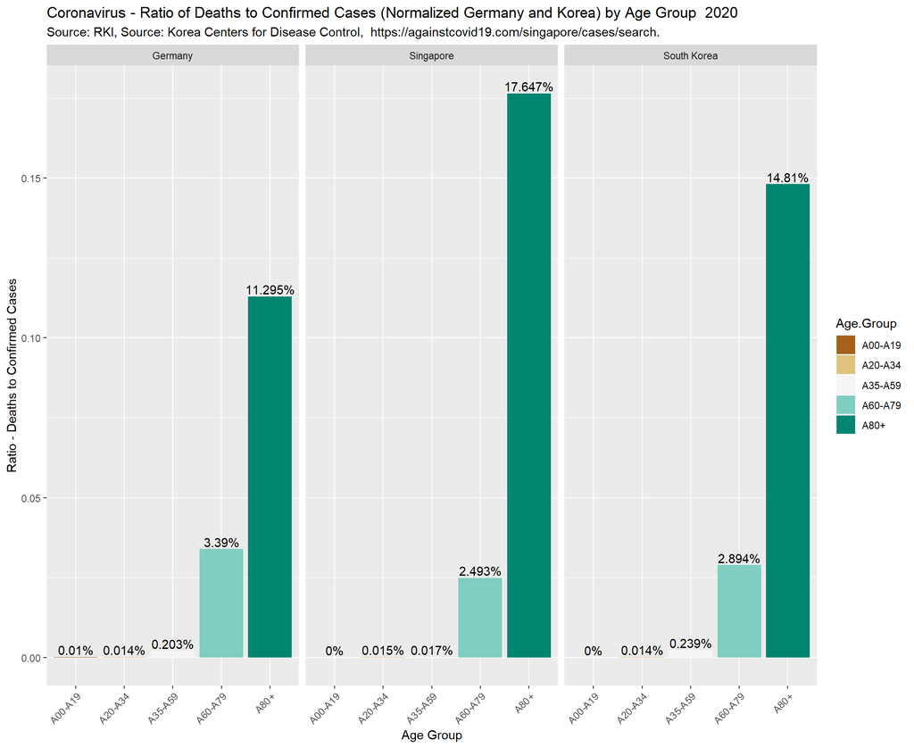

```r
#Ration has to be divided by corresponding divisor for Germany and Korea


Confirmed.Cases.Deaths$Ratio.death.case2 = NA

Confirmed.Cases.Deaths[Confirmed.Cases.Deaths$Country=="South Korea","Ratio.death.case2"] = Confirmed.Cases.Deaths[Confirmed.Cases.Deaths$Country=="South Korea","Ratio.death.case"]/Divisor.Korea

Confirmed.Cases.Deaths[ Confirmed.Cases.Deaths$Country=="Germany","Ratio.death.case2"] = Confirmed.Cases.Deaths[Confirmed.Cases.Deaths$Country=="Germany","Ratio.death.case"]/Divisor.Germany


Confirmed.Cases.Deaths[Confirmed.Cases.Deaths$Country=="Singapore","Ratio.death.case2"] = Confirmed.Cases.Deaths[Confirmed.Cases.Deaths$Country=="Singapore","Ratio.death.case"]


Confirmed.Cases.Deaths$Percent2 = paste(round(Confirmed.Cases.Deaths$Ratio.death.case2,5)*100,"%",sep="")

ggplot(Confirmed.Cases.Deaths, aes(x=Age.Group, y=Ratio.death.case2, fill = Age.Group))+geom_bar(stat="identity") + labs(subtitle="Source: RKI, Source: Korea Centers for Disease Control,  https://againstcovid19.com/singapore/cases/search.",
         title= "Coronavirus - Ratio of Deaths to Confirmed Cases (Normalized Germany and Korea) by Age Group  2020") + theme(axis.text.x = element_text(angle = 45, hjust = 1)) + scale_fill_brewer(palette = "BrBG") + xlab("Age Group") + ylab("Ratio - Deaths to Confirmed Cases") + geom_text(aes(label=Percent2), position=position_dodge(width=0.9), vjust=-0.25) + facet_wrap(. ~ Country)
```

When comparing Germany, Korea and Sinapore after assuming that for the first 2 countries they have probably captured less than half of the COVID cases we can see that the information is similar. Singapore, South Korea and Germany are now well aligned